# **Pandas**

### **What is Pandas**

A Python library providing data structures and data analysis tools. In particular, it offers data structures and operations for manipulating numerical tables and time series. The name comes from "panel data", an econometrics term for data sets that include observations over multiple time periods for the same individuals.

### **Benefits**

- Efficient storage and processing of data.
- Includes many built in functions for data transformation, aggregations, and plotting.
- Great for exploratory work.

### **Pandas is built on Numpy**

Numpy is one of the fundamental packages for scientific computing in Python.

- They are like lists in Python however they allow faster computation
  - They are stored as one contiguous block of memory, rather than being spread out across multiple locations like a list.
  - Each item in a numpy array is of the same data type (i.e. all integers, all floats, etc.), rather than a conglomerate of any number of data types (as a list is).

```python
import pandas as pd
import numpy as np
import matplotlib.pyplot as plt
# By convention
from numpy.random import randn
#return samples from the standard normal distribution
```

```python
np.random.randn(3,4)
```

```
array([[ 0.15705567, -0.53229413, -0.56556602, -0.90363394],
       [ 0.02396642, -0.61114129,  0.85944851,  0.75094198],
       [ 0.48659273, -0.17833593,  1.01057687,  0.00202565]])
```

### **Pandas Series**

Series is a one-dimensional labeled array capable of holding any data type (integers, strings, floating point numbers, Python objects, etc.).

```python
dt_index = pd.date_range('2015-1-1',
                        '2015-11-1',
                        freq='m')
dt_series = pd.Series(randn(10),
                      index = dt_index)
dt_series
```

```
2015-01-31   -0.610741
2015-02-28    2.135324
2015-03-31   -0.724126
2015-04-30   -0.056732
2015-05-31   -0.163344
2015-06-30   -1.809111
2015-07-31    0.748215
2015-08-31   -0.510318
2015-09-30    1.336520
2015-10-31   -0.756852
Freq: M, dtype: float64
```

```python
type(dt_series)
```

```
pandas.core.series.Series
```

```python
dt_series.mean()
```

```
-0.04111656845158672
```

### **Pandas DataFrames**

A set of Pandas Series that share the same index

```python
df = pd.DataFrame(randn(10, 5), index=dt_index, columns=[x for x in 'abcde'])
df
```

|  | a | b | c | d | e |
| --- | --- | --- | --- | --- | --- |
| 2015-01-31 | -0.606261 | -0.111042 | -1.097014 | 0.225621 | 1.316132 |
| 2015-02-28 | 0.159944 | 1.265508 | -0.689348 | 0.799481 | -1.003818 |
| 2015-03-31 | -0.641932 | 1.475988 | 1.616184 | 0.960701 | -1.162895 |
| 2015-04-30 | -0.422092 | 0.268672 | 0.315747 | -0.311609 | 1.079811 |
| 2015-05-31 | 0.762332 | 0.529420 | 2.218527 | -0.707606 | 1.466735 |
| 2015-06-30 | 0.413518 | -0.802546 | -0.451326 | -1.814800 | -0.821017 |
| 2015-07-31 | -1.038346 | 1.111153 | 0.356954 | -1.678583 | 0.729438 |
| 2015-08-31 | 0.787961 | -1.418694 | -0.853641 | -0.985456 | -0.544357 |
| 2015-09-30 | -1.915163 | 0.241606 | -0.779002 | 0.642172 | 1.250826 |
| 2015-10-31 | 4.043589 | -0.012271 | 0.798781 | 1.324500 | -0.178649 |

```python
type(df)
```

```
pandas.core.frame.DataFrame
```

```python
df['a']
#Select a column
```

```
2015-01-31   -0.606261
2015-02-28    0.159944
2015-03-31   -0.641932
2015-04-30   -0.422092
2015-05-31    0.762332
2015-06-30    0.413518
2015-07-31   -1.038346
2015-08-31    0.787961
2015-09-30   -1.915163
2015-10-31    4.043589
Freq: M, Name: a, dtype: float64
```

```python
df.a
#This may fail when your column has the same name as a
# dataframe method
```

```
2015-01-31   -0.606261
2015-02-28    0.159944
2015-03-31   -0.641932
2015-04-30   -0.422092
2015-05-31    0.762332
2015-06-30    0.413518
2015-07-31   -1.038346
2015-08-31    0.787961
2015-09-30   -1.915163
2015-10-31    4.043589
Freq: M, Name: a, dtype: float64
```

```python
df.loc['2015-10-31']
#select one row
```

```
a    4.043589
b   -0.012271
c    0.798781
d    1.324500
e   -0.178649
Name: 2015-10-31 00:00:00, dtype: float64
```

```python
col = df['a']
col.index
```

```
DatetimeIndex(['2015-01-31', '2015-02-28', '2015-03-31', '2015-04-30',
               '2015-05-31', '2015-06-30', '2015-07-31', '2015-08-31',
               '2015-09-30', '2015-10-31'],
              dtype='datetime64[ns]', freq='M')
```

```python
df[['a','b']]
#Select multiple columns
#Interior brackets are for list,
#outside brackets are indexing operator.
#Must use double brackets if to select tow or more columns.
```

|  | a | b |
| --- | --- | --- |
| 2015-01-31 | -0.606261 | -0.111042 |
| 2015-02-28 | 0.159944 | 1.265508 |
| 2015-03-31 | -0.641932 | 1.475988 |
| 2015-04-30 | -0.422092 | 0.268672 |
| 2015-05-31 | 0.762332 | 0.529420 |
| 2015-06-30 | 0.413518 | -0.802546 |
| 2015-07-31 | -1.038346 | 1.111153 |
| 2015-08-31 | 0.787961 | -1.418694 |
| 2015-09-30 | -1.915163 | 0.241606 |
| 2015-10-31 | 4.043589 | -0.012271 |

```python
df['a'] + df['b']
#Do math within columns
```

```
2015-01-31   -0.717303
2015-02-28    1.425452
2015-03-31    0.834056
2015-04-30   -0.153420
2015-05-31    1.291752
2015-06-30   -0.389029
2015-07-31    0.072807
2015-08-31   -0.630733
2015-09-30   -1.673558
2015-10-31    4.031319
Freq: M, dtype: float64
```

```python
df['h'] = df['a'] + df['b']
#Adding a new column
```

```python
df.head()
```

|  | a | b | c | d | e | h |
| --- | --- | --- | --- | --- | --- | --- |
| 2015-01-31 | -0.606261 | -0.111042 | -1.097014 | 0.225621 | 1.316132 | -0.717303 |
| 2015-02-28 | 0.159944 | 1.265508 | -0.689348 | 0.799481 | -1.003818 | 1.425452 |
| 2015-03-31 | -0.641932 | 1.475988 | 1.616184 | 0.960701 | -1.162895 | 0.834056 |
| 2015-04-30 | -0.422092 | 0.268672 | 0.315747 | -0.311609 | 1.079811 | -0.153420 |
| 2015-05-31 | 0.762332 | 0.529420 | 2.218527 | -0.707606 | 1.466735 | 1.291752 |

```python
df.loc['2015-05-31':'2015-08-31', 'c':'e']
#Select by index and column label
```

|  | c | d | e |
| --- | --- | --- | --- |
| 2015-05-31 | 2.218527 | -0.707606 | 1.466735 |
| 2015-06-30 | -0.451326 | -1.814800 | -0.821017 |
| 2015-07-31 | 0.356954 | -1.678583 | 0.729438 |
| 2015-08-31 | -0.853641 | -0.985456 | -0.544357 |

```python
df.iloc[2:4,2:5]
#Slect by slicing
```

|  | c | d | e |
| --- | --- | --- | --- |
| 2015-03-31 | 1.616184 | 0.960701 | -1.162895 |
| 2015-04-30 | 0.315747 | -0.311609 | 1.079811 |

### **How Pandas works with imported data**

```python
df = pd.read_csv('IMDB-Movie-Data.csv')
#https://www.kaggle.com/PromptCloudHQ/imdb-data
df.head()
```

|  | Rank | Title | Genre | Description | Director | Actors | Year | Runtime (Minutes) | Rating | Votes | Revenue (Millions) | Metascore |
| --- | --- | --- | --- | --- | --- | --- | --- | --- | --- | --- | --- | --- |
| 0 | 1 | Guardians of the Galaxy | Action,Adventure,Sci-Fi | A group of intergalactic criminals are forced ... | James Gunn | Chris Pratt, Vin Diesel, Bradley Cooper, Zoe S... | 2014 | 121 | 8.1 | 757074 | 333.13 | 76.0 |
| 1 | 2 | Prometheus | Adventure,Mystery,Sci-Fi | Following clues to the origin of mankind, a te... | Ridley Scott | Noomi Rapace, Logan Marshall-Green, Michael Fa... | 2012 | 124 | 7.0 | 485820 | 126.46 | 65.0 |
| 2 | 3 | Split | Horror,Thriller | Three girls are kidnapped by a man with a diag... | M. Night Shyamalan | James McAvoy, Anya Taylor-Joy, Haley Lu Richar... | 2016 | 117 | 7.3 | 157606 | 138.12 | 62.0 |
| 3 | 4 | Sing | Animation,Comedy,Family | In a city of humanoid animals, a hustling thea... | Christophe Lourdelet | Matthew McConaughey,Reese Witherspoon, Seth Ma... | 2016 | 108 | 7.2 | 60545 | 270.32 | 59.0 |
| 4 | 5 | Suicide Squad | Action,Adventure,Fantasy | A secret government agency recruits some of th... | David Ayer | Will Smith, Jared Leto, Margot Robbie, Viola D... | 2016 | 123 | 6.2 | 393727 | 325.02 | 40.0 |

```python
df.shape
```

```
(1000, 12)
```

```python
df.columns
```

```
Index(['Rank', 'Title', 'Genre', 'Description', 'Director', 'Actors', 'Year',
       'Runtime (Minutes)', 'Rating', 'Votes', 'Revenue (Millions)',
       'Metascore'],
      dtype='object')
```

```python
df.info()
```

```
<class 'pandas.core.frame.DataFrame'>
RangeIndex: 1000 entries, 0 to 999
Data columns (total 12 columns):
Rank                  1000 non-null int64
Title                 1000 non-null object
Genre                 1000 non-null object
Description           1000 non-null object
Director              1000 non-null object
Actors                1000 non-null object
Year                  1000 non-null int64
Runtime (Minutes)     1000 non-null int64
Rating                1000 non-null float64
Votes                 1000 non-null int64
Revenue (Millions)    872 non-null float64
Metascore             936 non-null float64
dtypes: float64(3), int64(4), object(5)
memory usage: 93.8+ KB
```

```python
df['Rating']
```

```
0      8.1
1      7.0
2      7.3
3      7.2
4      6.2
5      6.1
6      8.3
7      6.4
8      7.1
9      7.0
10     7.5
11     7.8
12     7.9
13     7.7
14     6.4
```

[output cut: 47 more lines]

```python
df['Rating'] <= 7
```

```
0      False
1       True
2      False
3      False
4       True
5       True
6      False
7       True
8      False
9       True
10     False
11     False
12     False
13     False
14      True
```

[output cut: 47 more lines]

```python
mask = df['Rating'] <= 7
```

```python
df[mask].head()
#Use boolean series to mask a datafram
#returning only those rows where the mask is True
```

|  | Rank | Title | Genre | Description | Director | Actors | Year | Runtime (Minutes) | Rating | Votes | Revenue (Millions) | Metascore |
| --- | --- | --- | --- | --- | --- | --- | --- | --- | --- | --- | --- | --- |
| 1 | 2 | Prometheus | Adventure,Mystery,Sci-Fi | Following clues to the origin of mankind, a te... | Ridley Scott | Noomi Rapace, Logan Marshall-Green, Michael Fa... | 2012 | 124 | 7.0 | 485820 | 126.46 | 65.0 |
| 4 | 5 | Suicide Squad | Action,Adventure,Fantasy | A secret government agency recruits some of th... | David Ayer | Will Smith, Jared Leto, Margot Robbie, Viola D... | 2016 | 123 | 6.2 | 393727 | 325.02 | 40.0 |
| 5 | 6 | The Great Wall | Action,Adventure,Fantasy | European mercenaries searching for black powde... | Yimou Zhang | Matt Damon, Tian Jing, Willem Dafoe, Andy Lau | 2016 | 103 | 6.1 | 56036 | 45.13 | 42.0 |
| 7 | 8 | Mindhorn | Comedy | A has-been actor best known for playing the ti... | Sean Foley | Essie Davis, Andrea Riseborough, Julian Barrat... | 2016 | 89 | 6.4 | 2490 | NaN | 71.0 |
| 9 | 10 | Passengers | Adventure,Drama,Romance | A spacecraft traveling to a distant colony pla... | Morten Tyldum | Jennifer Lawrence, Chris Pratt, Michael Sheen,... | 2016 | 116 | 7.0 | 192177 | 100.01 | 41.0 |

```python
g = df.groupby('Year').count()['Title']
g
```

```
Year
2006     44
2007     53
2008     52
2009     51
2010     60
2011     63
2012     64
2013     91
2014     98
2015    127
2016    297
Name: Title, dtype: int64
```

```python
df.drop('Votes', axis=1)
#drop a column
```

|  | Rank | Title | Genre | Description | Director | Actors | Year | Runtime (Minutes) | Rating | Revenue (Millions) | Metascore |
| --- | --- | --- | --- | --- | --- | --- | --- | --- | --- | --- | --- |
| 0 | 1 | Guardians of the Galaxy | Action,Adventure,Sci-Fi | A group of intergalactic criminals are forced ... | James Gunn | Chris Pratt, Vin Diesel, Bradley Cooper, Zoe S... | 2014 | 121 | 8.1 | 333.13 | 76.0 |
| 1 | 2 | Prometheus | Adventure,Mystery,Sci-Fi | Following clues to the origin of mankind, a te... | Ridley Scott | Noomi Rapace, Logan Marshall-Green, Michael Fa... | 2012 | 124 | 7.0 | 126.46 | 65.0 |
| 2 | 3 | Split | Horror,Thriller | Three girls are kidnapped by a man with a diag... | M. Night Shyamalan | James McAvoy, Anya Taylor-Joy, Haley Lu Richar... | 2016 | 117 | 7.3 | 138.12 | 62.0 |
| 3 | 4 | Sing | Animation,Comedy,Family | In a city of humanoid animals, a hustling thea... | Christophe Lourdelet | Matthew McConaughey,Reese Witherspoon, Seth Ma... | 2016 | 108 | 7.2 | 270.32 | 59.0 |
| 4 | 5 | Suicide Squad | Action,Adventure,Fantasy | A secret government agency recruits some of th... | David Ayer | Will Smith, Jared Leto, Margot Robbie, Viola D... | 2016 | 123 | 6.2 | 325.02 | 40.0 |
| 5 | 6 | The Great Wall | Action,Adventure,Fantasy | European mercenaries searching for black powde... | Yimou Zhang | Matt Damon, Tian Jing, Willem Dafoe, Andy Lau | 2016 | 103 | 6.1 | 45.13 | 42.0 |
| 6 | 7 | La La Land | Comedy,Drama,Music | A jazz pianist falls for an aspiring actress i... | Damien Chazelle | Ryan Gosling, Emma Stone, Rosemarie DeWitt, J.... | 2016 | 128 | 8.3 | 151.06 | 93.0 |
| 7 | 8 | Mindhorn | Comedy | A has-been actor best known for playing the ti... | Sean Foley | Essie Davis, Andrea Riseborough, Julian Barrat... | 2016 | 89 | 6.4 | NaN | 71.0 |
| 8 | 9 | The Lost City of Z | Action,Adventure,Biography | A true-life drama, centering on British explor... | James Gray | Charlie Hunnam, Robert Pattinson, Sienna Mille... | 2016 | 141 | 7.1 | 8.01 | 78.0 |
| 9 | 10 | Passengers | Adventure,Drama,Romance | A spacecraft traveling to a distant colony pla... | Morten Tyldum | Jennifer Lawrence, Chris Pratt, Michael Sheen,... | 2016 | 116 | 7.0 | 100.01 | 41.0 |
| 10 | 11 | Fantastic Beasts and Where to Find Them | Adventure,Family,Fantasy | The adventures of writer Newt Scamander in New... | David Yates | Eddie Redmayne, Katherine Waterston, Alison Su... | 2016 | 133 | 7.5 | 234.02 | 66.0 |
| 11 | 12 | Hidden Figures | Biography,Drama,History | The story of a team of female African-American... | Theodore Melfi | Taraji P. Henson, Octavia Spencer, Janelle Mon... | 2016 | 127 | 7.8 | 169.27 | 74.0 |
| 12 | 13 | Rogue One | Action,Adventure,Sci-Fi | The Rebel Alliance makes a risky move to steal... | Gareth Edwards | Felicity Jones, Diego Luna, Alan Tudyk, Donnie... | 2016 | 133 | 7.9 | 532.17 | 65.0 |
| 13 | 14 | Moana | Animation,Adventure,Comedy | In Ancient Polynesia, when a terrible curse in... | Ron Clements | Auli'i Cravalho, Dwayne Johnson, Rachel House,... | 2016 | 107 | 7.7 | 248.75 | 81.0 |
| 14 | 15 | Colossal | Action,Comedy,Drama | Gloria is an out-of-work party girl forced to ... | Nacho Vigalondo | Anne Hathaway, Jason Sudeikis, Austin Stowell,... | 2016 | 109 | 6.4 | 2.87 | 70.0 |
| 15 | 16 | The Secret Life of Pets | Animation,Adventure,Comedy | The quiet life of a terrier named Max is upend... | Chris Renaud | Louis C.K., Eric Stonestreet, Kevin Hart, Lake... | 2016 | 87 | 6.6 | 368.31 | 61.0 |
| 16 | 17 | Hacksaw Ridge | Biography,Drama,History | WWII American Army Medic Desmond T. Doss, who ... | Mel Gibson | Andrew Garfield, Sam Worthington, Luke Bracey,... | 2016 | 139 | 8.2 | 67.12 | 71.0 |
| 17 | 18 | Jason Bourne | Action,Thriller | The CIA's most dangerous former operative is d... | Paul Greengrass | Matt Damon, Tommy Lee Jones, Alicia Vikander,V... | 2016 | 123 | 6.7 | 162.16 | 58.0 |
| 18 | 19 | Lion | Biography,Drama | A five-year-old Indian boy gets lost on the st... | Garth Davis | Dev Patel, Nicole Kidman, Rooney Mara, Sunny P... | 2016 | 118 | 8.1 | 51.69 | 69.0 |
| 19 | 20 | Arrival | Drama,Mystery,Sci-Fi | When twelve mysterious spacecraft appear aroun... | Denis Villeneuve | Amy Adams, Jeremy Renner, Forest Whitaker,Mich... | 2016 | 116 | 8.0 | 100.50 | 81.0 |
| 20 | 21 | Gold | Adventure,Drama,Thriller | Kenny Wells, a prospector desperate for a luck... | Stephen Gaghan | Matthew McConaughey, Edgar Ramírez, Bryce Dall... | 2016 | 120 | 6.7 | 7.22 | 49.0 |
| 21 | 22 | Manchester by the Sea | Drama | A depressed uncle is asked to take care of his... | Kenneth Lonergan | Casey Affleck, Michelle Williams, Kyle Chandle... | 2016 | 137 | 7.9 | 47.70 | 96.0 |
| 22 | 23 | Hounds of Love | Crime,Drama,Horror | A cold-blooded predatory couple while cruising... | Ben Young | Emma Booth, Ashleigh Cummings, Stephen Curry,S... | 2016 | 108 | 6.7 | NaN | 72.0 |
| 23 | 24 | Trolls | Animation,Adventure,Comedy | After the Bergens invade Troll Village, Poppy,... | Walt Dohrn | Anna Kendrick, Justin Timberlake,Zooey Deschan... | 2016 | 92 | 6.5 | 153.69 | 56.0 |
| 24 | 25 | Independence Day: Resurgence | Action,Adventure,Sci-Fi | Two decades after the first Independence Day i... | Roland Emmerich | Liam Hemsworth, Jeff Goldblum, Bill Pullman,Ma... | 2016 | 120 | 5.3 | 103.14 | 32.0 |
| 25 | 26 | Paris pieds nus | Comedy | Fiona visits Paris for the first time to assis... | Dominique Abel | Fiona Gordon, Dominique Abel,Emmanuelle Riva, ... | 2016 | 83 | 6.8 | NaN | NaN |
| 26 | 27 | Bahubali: The Beginning | Action,Adventure,Drama | In ancient India, an adventurous and daring ma... | S.S. Rajamouli | Prabhas, Rana Daggubati, Anushka Shetty,Tamann... | 2015 | 159 | 8.3 | 6.50 | NaN |
| 27 | 28 | Dead Awake | Horror,Thriller | A young woman must save herself and her friend... | Phillip Guzman | Jocelin Donahue, Jesse Bradford, Jesse Borrego... | 2016 | 99 | 4.7 | 0.01 | NaN |
| 28 | 29 | Bad Moms | Comedy | When three overworked and under-appreciated mo... | Jon Lucas | Mila Kunis, Kathryn Hahn, Kristen Bell,Christi... | 2016 | 100 | 6.2 | 113.08 | 60.0 |
| 29 | 30 | Assassin's Creed | Action,Adventure,Drama | When Callum Lynch explores the memories of his... | Justin Kurzel | Michael Fassbender, Marion Cotillard, Jeremy I... | 2016 | 115 | 5.9 | 54.65 | 36.0 |
| ... | ... | ... | ... | ... | ... | ... | ... | ... | ... | ... | ... |
| 970 | 971 | Texas Chainsaw 3D | Horror,Thriller | A young woman travels to Texas to collect an i... | John Luessenhop | Alexandra Daddario, Tania Raymonde, Scott East... | 2013 | 92 | 4.8 | 34.33 | 62.0 |
| 971 | 972 | Disturbia | Drama,Mystery,Thriller | A teen living under house arrest becomes convi... | D.J. Caruso | Shia LaBeouf, David Morse, Carrie-Anne Moss, S... | 2007 | 105 | 6.9 | 80.05 | NaN |
| 972 | 973 | Rock of Ages | Comedy,Drama,Musical | A small town girl and a city boy meet on the S... | Adam Shankman | Julianne Hough, Diego Boneta, Tom Cruise, Alec... | 2012 | 123 | 5.9 | 38.51 | 47.0 |
| 973 | 974 | Scream 4 | Horror,Mystery | Ten years have passed, and Sidney Prescott, wh... | Wes Craven | Neve Campbell, Courteney Cox, David Arquette, ... | 2011 | 111 | 6.2 | 38.18 | 52.0 |
| 974 | 975 | Queen of Katwe | Biography,Drama,Sport | A Ugandan girl sees her world rapidly change a... | Mira Nair | Madina Nalwanga, David Oyelowo, Lupita Nyong'o... | 2016 | 124 | 7.4 | 8.81 | 73.0 |
| 975 | 976 | My Big Fat Greek Wedding 2 | Comedy,Family,Romance | A Portokalos family secret brings the beloved ... | Kirk Jones | Nia Vardalos, John Corbett, Michael Constantin... | 2016 | 94 | 6.0 | 59.57 | 37.0 |
| 976 | 977 | Dark Places | Drama,Mystery,Thriller | Libby Day was only eight years old when her fa... | Gilles Paquet-Brenner | Charlize Theron, Nicholas Hoult, Christina Hen... | 2015 | 113 | 6.2 | NaN | 39.0 |
| 977 | 978 | Amateur Night | Comedy | Guy Carter is an award-winning graduate studen... | Lisa Addario | Jason Biggs, Janet Montgomery,Ashley Tisdale, ... | 2016 | 92 | 5.0 | NaN | 38.0 |
| 978 | 979 | It's Only the End of the World | Drama | Louis (Gaspard Ulliel), a terminally ill write... | Xavier Dolan | Nathalie Baye, Vincent Cassel, Marion Cotillar... | 2016 | 97 | 7.0 | NaN | 48.0 |
| 979 | 980 | The Skin I Live In | Drama,Thriller | A brilliant plastic surgeon, haunted by past t... | Pedro Almodóvar | Antonio Banderas, Elena Anaya, Jan Cornet,Mari... | 2011 | 120 | 7.6 | 3.19 | 70.0 |
| 980 | 981 | Miracles from Heaven | Biography,Drama,Family | A young girl suffering from a rare digestive d... | Patricia Riggen | Jennifer Garner, Kylie Rogers, Martin Henderso... | 2016 | 109 | 7.0 | 61.69 | 44.0 |
| 981 | 982 | Annie | Comedy,Drama,Family | A foster kid, who lives with her mean foster m... | Will Gluck | Quvenzhané Wallis, Cameron Diaz, Jamie Foxx, R... | 2014 | 118 | 5.3 | 85.91 | 33.0 |
| 982 | 983 | Across the Universe | Drama,Fantasy,Musical | The music of the Beatles and the Vietnam War f... | Julie Taymor | Evan Rachel Wood, Jim Sturgess, Joe Anderson, ... | 2007 | 133 | 7.4 | 24.34 | 56.0 |
| 983 | 984 | Let's Be Cops | Comedy | Two struggling pals dress as police officers f... | Luke Greenfield | Jake Johnson, Damon Wayans Jr., Rob Riggle, Ni... | 2014 | 104 | 6.5 | 82.39 | 30.0 |
| 984 | 985 | Max | Adventure,Family | A Malinois dog that helped American Marines in... | Boaz Yakin | Thomas Haden Church, Josh Wiggins, Luke Kleint... | 2015 | 111 | 6.8 | 42.65 | 47.0 |
| 985 | 986 | Your Highness | Adventure,Comedy,Fantasy | When Prince Fabious's bride is kidnapped, he g... | David Gordon Green | Danny McBride, Natalie Portman, James Franco, ... | 2011 | 102 | 5.6 | 21.56 | 31.0 |
| 986 | 987 | Final Destination 5 | Horror,Thriller | Survivors of a suspension-bridge collapse lear... | Steven Quale | Nicholas D'Agosto, Emma Bell, Arlen Escarpeta,... | 2011 | 92 | 5.9 | 42.58 | 50.0 |
| 987 | 988 | Endless Love | Drama,Romance | The story of a privileged girl and a charismat... | Shana Feste | Gabriella Wilde, Alex Pettyfer, Bruce Greenwoo... | 2014 | 104 | 6.3 | 23.39 | 30.0 |
| 988 | 989 | Martyrs | Horror | A young woman's quest for revenge against the ... | Pascal Laugier | Morjana Alaoui, Mylène Jampanoï, Catherine Bég... | 2008 | 99 | 7.1 | NaN | 89.0 |
| 989 | 990 | Selma | Biography,Drama,History | A chronicle of Martin Luther King's campaign t... | Ava DuVernay | David Oyelowo, Carmen Ejogo, Tim Roth, Lorrain... | 2014 | 128 | 7.5 | 52.07 | NaN |
| 990 | 991 | Underworld: Rise of the Lycans | Action,Adventure,Fantasy | An origins story centered on the centuries-old... | Patrick Tatopoulos | Rhona Mitra, Michael Sheen, Bill Nighy, Steven... | 2009 | 92 | 6.6 | 45.80 | 44.0 |
| 991 | 992 | Taare Zameen Par | Drama,Family,Music | An eight-year-old boy is thought to be a lazy ... | Aamir Khan | Darsheel Safary, Aamir Khan, Tanay Chheda, Sac... | 2007 | 165 | 8.5 | 1.20 | 42.0 |
| 992 | 993 | Take Me Home Tonight | Comedy,Drama,Romance | Four years after graduation, an awkward high s... | Michael Dowse | Topher Grace, Anna Faris, Dan Fogler, Teresa P... | 2011 | 97 | 6.3 | 6.92 | NaN |
| 993 | 994 | Resident Evil: Afterlife | Action,Adventure,Horror | While still out to destroy the evil Umbrella C... | Paul W.S. Anderson | Milla Jovovich, Ali Larter, Wentworth Miller,K... | 2010 | 97 | 5.9 | 60.13 | 37.0 |
| 994 | 995 | Project X | Comedy | 3 high school seniors throw a birthday party t... | Nima Nourizadeh | Thomas Mann, Oliver Cooper, Jonathan Daniel Br... | 2012 | 88 | 6.7 | 54.72 | 48.0 |
| 995 | 996 | Secret in Their Eyes | Crime,Drama,Mystery | A tight-knit team of rising investigators, alo... | Billy Ray | Chiwetel Ejiofor, Nicole Kidman, Julia Roberts... | 2015 | 111 | 6.2 | NaN | 45.0 |
| 996 | 997 | Hostel: Part II | Horror | Three American college students studying abroa... | Eli Roth | Lauren German, Heather Matarazzo, Bijou Philli... | 2007 | 94 | 5.5 | 17.54 | 46.0 |
| 997 | 998 | Step Up 2: The Streets | Drama,Music,Romance | Romantic sparks occur between two dance studen... | Jon M. Chu | Robert Hoffman, Briana Evigan, Cassie Ventura,... | 2008 | 98 | 6.2 | 58.01 | 50.0 |
| 998 | 999 | Search Party | Adventure,Comedy | A pair of friends embark on a mission to reuni... | Scot Armstrong | Adam Pally, T.J. Miller, Thomas Middleditch,Sh... | 2014 | 93 | 5.6 | NaN | 22.0 |
| 999 | 1000 | Nine Lives | Comedy,Family,Fantasy | A stuffy businessman finds himself trapped ins... | Barry Sonnenfeld | Kevin Spacey, Jennifer Garner, Robbie Amell,Ch... | 2016 | 87 | 5.3 | 19.64 | 11.0 |

1000 rows × 11 columns

```python
df.columns
```

```
Index(['Rank', 'Title', 'Genre', 'Description', 'Director', 'Actors', 'Year',
       'Runtime (Minutes)', 'Rating', 'Votes', 'Revenue (Millions)',
       'Metascore'],
      dtype='object')
```

```python
df['Genre'].value_counts()
#For categorical data, this gets you the frequencies
```

```
Action,Adventure,Sci-Fi       50
Drama                         48
Comedy,Drama,Romance          35
Comedy                        32
Drama,Romance                 31
Animation,Adventure,Comedy    27
Action,Adventure,Fantasy      27
Comedy,Drama                  27
Comedy,Romance                26
Crime,Drama,Thriller          24
Crime,Drama,Mystery           23
Action,Adventure,Drama        18
Action,Crime,Drama            17
Horror,Thriller               16
Drama,Thriller                15
Adventure,Family,Fantasy      14
Action,Adventure,Comedy       14
Biography,Drama               14
Biography,Drama,History       14
Action,Crime,Thriller         12
Action,Comedy,Crime           12
Action,Adventure,Thriller     11
Horror                        11
Crime,Drama                   10
Animation,Action,Adventure     9
Biography,Crime,Drama          9
Thriller                       9
Horror,Mystery,Thriller        9
Action,Thriller                9
Drama,Mystery,Thriller         8
                              ..
Action,Fantasy,War             1
Drama,Fantasy,Music            1
Sci-Fi,Thriller                1
Comedy,Western                 1
Fantasy,Horror,Thriller        1
Comedy,Family,Romance          1
Biography,History,Thriller     1
Comedy,Horror,Romance          1
Crime,Thriller                 1
Comedy,Drama,Thriller          1
Action,Fantasy                 1
Mystery,Romance,Thriller       1
Comedy,Romance,Sport           1
Drama,Fantasy,Thriller         1
Drama,Fantasy,Mystery          1
Biography,Drama,Mystery        1
Fantasy,Mystery,Thriller       1
Drama,Romance,War              1
Thriller,War                   1
Adventure,Drama,War            1
Adventure,Fantasy,Mystery      1
Action,Comedy,Sci-Fi           1
Adventure,Comedy,Fantasy       1
Action,Horror,Romance          1
Romance,Sci-Fi                 1
Drama,Thriller,War             1
Animation,Comedy,Drama         1
Animation,Fantasy              1
Drama,Family                   1
Animation,Drama,Fantasy        1
Name: Genre, Length: 207, dtype: int64
```

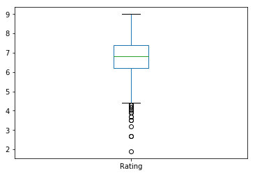

```python
df[['Rating']].plot(kind='box');
plt.show()
```

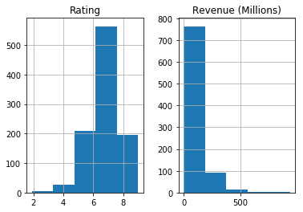

```python
df.hist(['Rating','Revenue (Millions)'],bins=5);
plt.show()
```

```python
groups=df.groupby('Year')
for name, group in groups:
    print(name)
```

```
2006
2007
2008
2009
2010
2011
2012
2013
2014
2015
2016
```

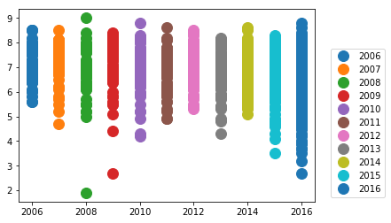

```python
fig, ax = plt.subplots()

ax.margins(0.05)
for name, group in groups:
    ax.plot(group.Year, group.Rating, marker='o', linestyle='', ms=12, label=name)
ax.legend(numpoints=1, loc='lower right', bbox_to_anchor=(1.25, 0.0))

plt.show()
```

### **Reference**

- https://en.wikipedia.org/wiki/Pandas_(software)
- http://pandas.pydata.org/pandas-docs/stable/index.html
- http://pandas.pydata.org/pandas-docs/stable/comparison_with_sql.html